# Report II - Analysis of SAR Samples

Ma siteng(simon), Liang shuang, Liu zhening(NiuNiu), Zhang yu

2020/10/21

## Implement the densities of the K and G0 distributions for intensity data

Import the bright image data from the “ImagematrXI” library for analysis.

```r
# Use your paths
source("../../Code/R/imagematrix.R")
load("../../Data/R/bright.Rdata")
# Inspect what they are in the Environment window
```

The reports are usually started with the very basic information about the data, including its type, dimension and range, etc.

```r
typeof(bright)
```

```
## [1] "double"
```

```r
dim(bright)
```

```
## [1] 109 214   3
```

```r
range(bright)
```

```
## [1] 6.265993e-01 1.046492e+08
```

```r
vector.bright <- data.frame(bright=as.vector(bright))
summary(vector.bright)
```

```
##      bright
##  Min.   :        1
##  1st Qu.:    24325
##  Median :    85451
##  Mean   :   469894
##  3rd Qu.:   277819
##  Max.   :104649217
```

When moving to graphical representations of the data, We can analyze the data with boxplot and histogram The outliers are shown in orange.

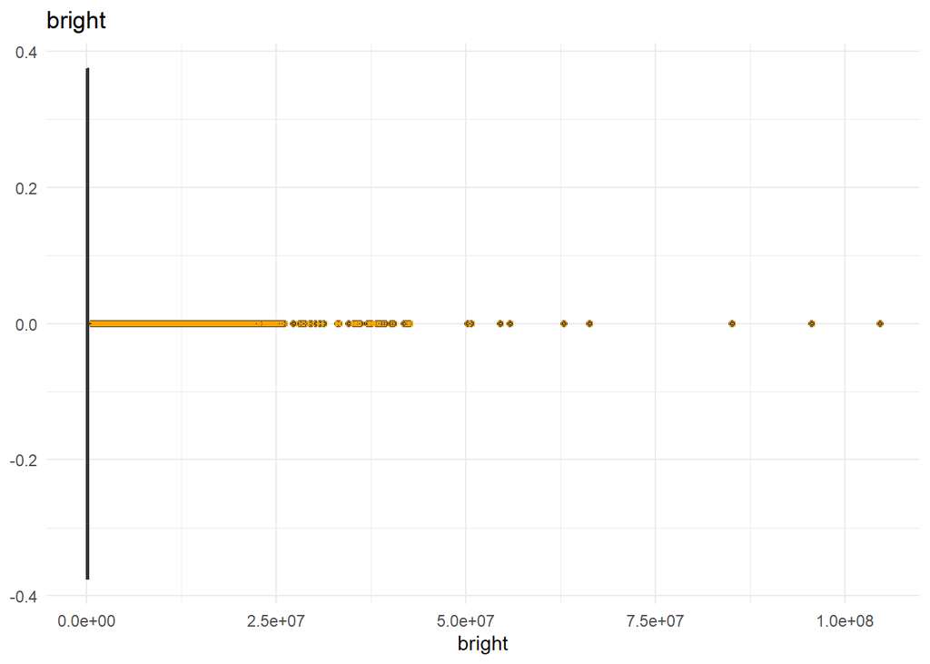

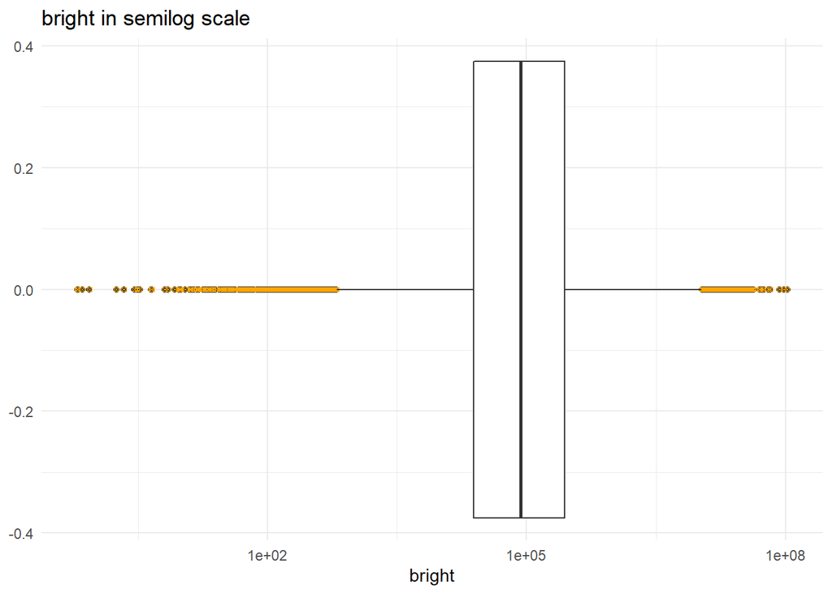

Boxplots with notches

```r
ggplot(vector.bright, aes(x=bright)) +
  geom_boxplot(notch = TRUE)+
  geom_boxplot(outlier.colour="orange", outlier.shape=7,outlier.size=1)+
  ggtitle("bright")

ggplot(vector.bright, aes(x=bright)) +
  geom_boxplot(notch = TRUE) +
  geom_boxplot(outlier.colour="orange", outlier.shape=7,outlier.size=1)+
  scale_x_log10()+
  ggtitle("bright in semilog scale")
```

Histograms of the data complement the information are shown by the boxplots. We also use the Freedman-Diaconis rule for building the histograms, which consists of using bins of equal size: $\frac32 \text{IQR}(z) / n^{1/3}$.

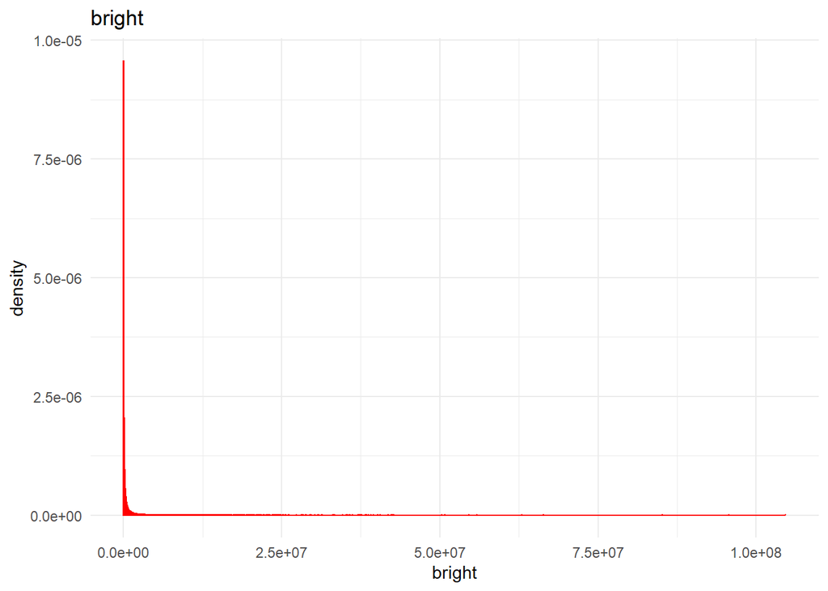

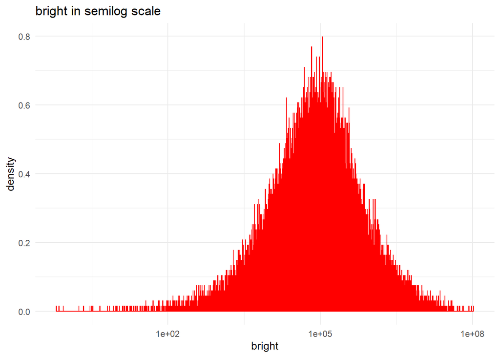

Histograms

```r
ggplot(vector.bright, aes(x=bright)) +
  geom_histogram(aes(y=..density..),
                 bins=nclass.FD(unlist(vector.bright)),
                 col="red", fill="white")+
  ggtitle("bright")

ggplot(vector.bright, aes(x=bright)) +
  geom_histogram(aes(y=..density..),
                 bins=nclass.FD(unlist(vector.bright)),
                 col="red", fill="white") +
  scale_x_log10()+
  ggtitle("bright in semilog scale")
```

Now we merge the second boxplot in the second histogram shown as following:

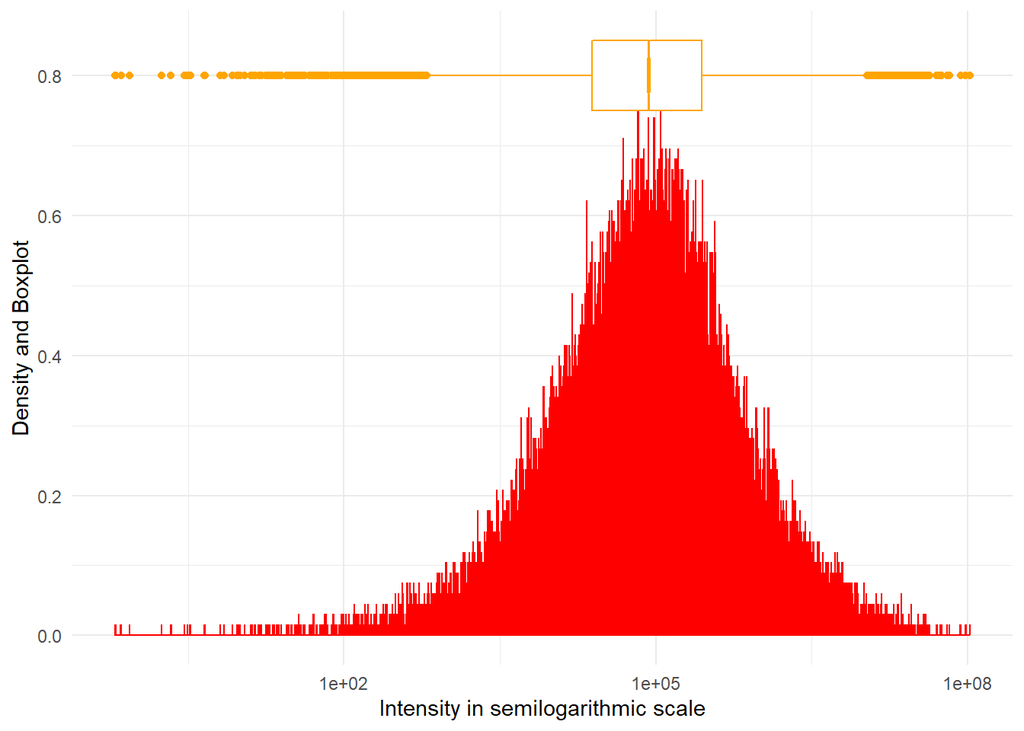

```r
ggplot(vector.bright, aes(x=bright)) +
  geom_histogram(aes(y=..density..),
                 bins=nclass.FD(unlist(vector.bright)),
                 col="red", fill="white") +
  geom_boxplot(aes(y=0.8), width=.1,col="orange", notch=TRUE) +
  ylab("Density and Boxplot") +
  xlab("Intensity in semilogarithmic scale") +
  scale_x_log10()
```

```r
# Try reducing the number of bins
```

Through the above analysis, we can obtain the following three conclusions:

- The data are positive
- The data have a very large dynamic range
- The data are some symmetric

Then, we can pay attention to the “natural” domain of the data: as an image. The “imagematrix” library requires the data with the range between $[0,1]$ and we perform a function to do this mapping.

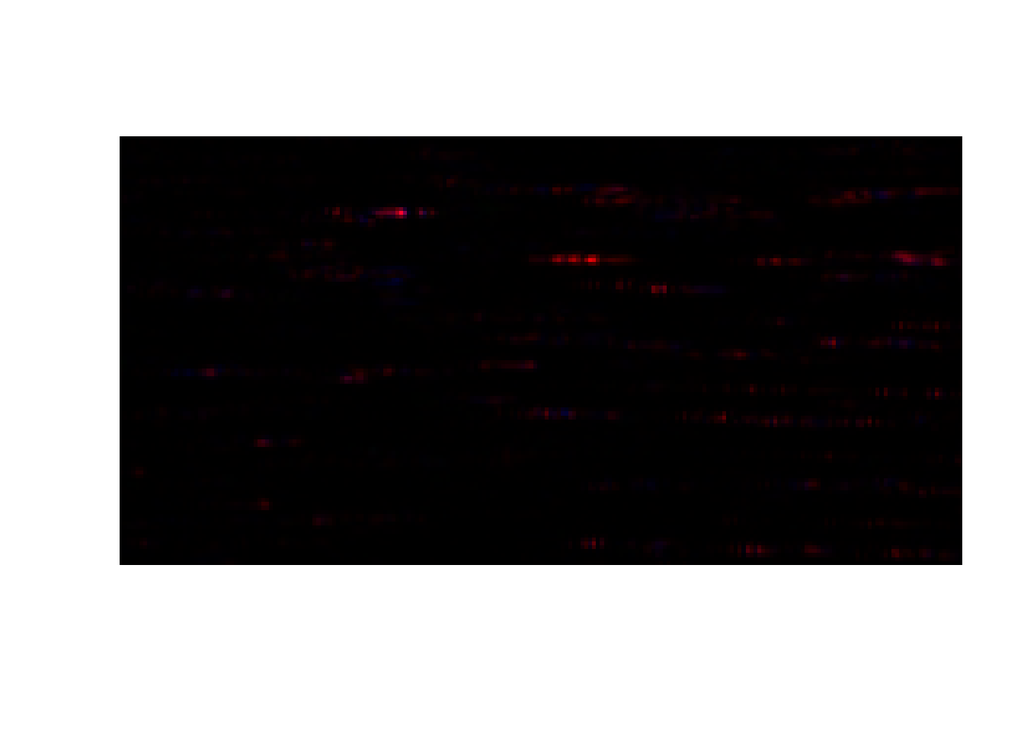

```r
plot(imagematrix(normalize(bright)))
```

However, there are little things that we can observe in the above image. The reason may be there are a few very large values that “flatten” most of the observations into very deep greyscales. Instead, We want to “use” all possible values equally. In other words, we want to have a uniform histogram.

Considering the cumulative distribution function $F_Z$ of the continuous random variable $Zcolon \Omega\to\mathbb R$, the random variable $W=F_Z(Z)$ has a uniform distribution.

Therefore, we need to apply the cumulative distribution function of the random variable generating the data to the data itself, and we’ll get a uniformly distributed sample. Unfortunately, we don’t have such function, but we can estimate it.

The original data and its empirical function are shown as following:

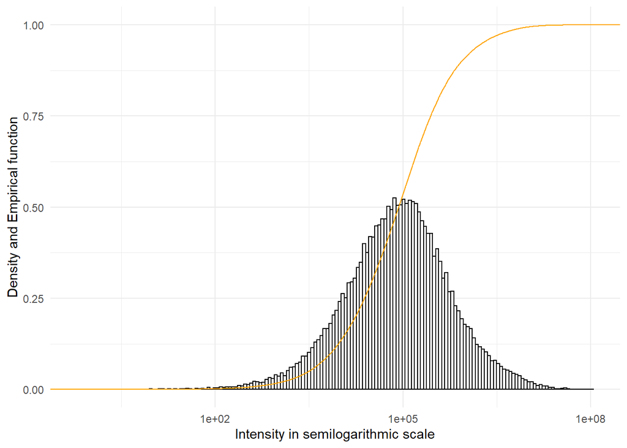

```r
ggplot(vector.bright, aes(x=bright)) +
  geom_histogram(aes(y=..density..),
                 bins=nclass.FD(unlist(vector.bright))/50,
                 col="black", fill="white") +
  stat_ecdf(col="orange") +
  ylab("Density and Empirical function") +
  xlab("Intensity in semilogarithmic scale") +
  scale_x_log10()
```

Such data can be implemented as:

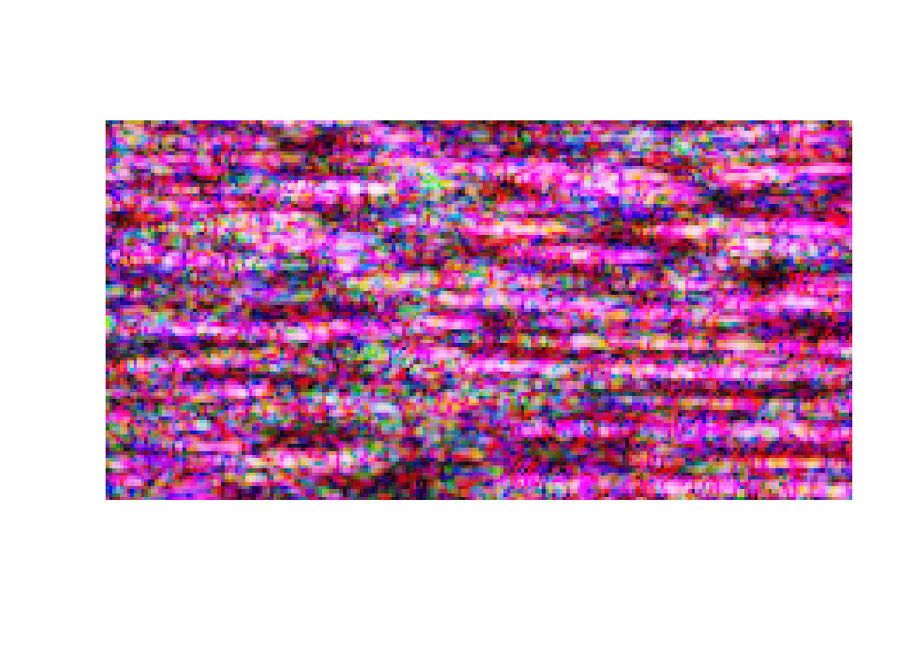

```r
# First, we compute the empirical function
ecdf.bright <- ecdf(unlist(vector.bright))

# Then, we apply this function to the data
eq.bright <- ecdf.bright(unlist(vector.bright))

# Finally, we restore the matrix organization of the data
dim(eq.bright) <- dim(bright)

# And we see the result
plot(imagematrix(eq.bright))
```

Now, we can perform an EDA on the equalized data.

```r
summary(as.vector(eq.bright))
```

```
##     Min.  1st Qu.   Median     Mean  3rd Qu.     Max.
## 1.43e-05 2.50e-01 5.00e-01 5.00e-01 7.50e-01 1.00e+00
```

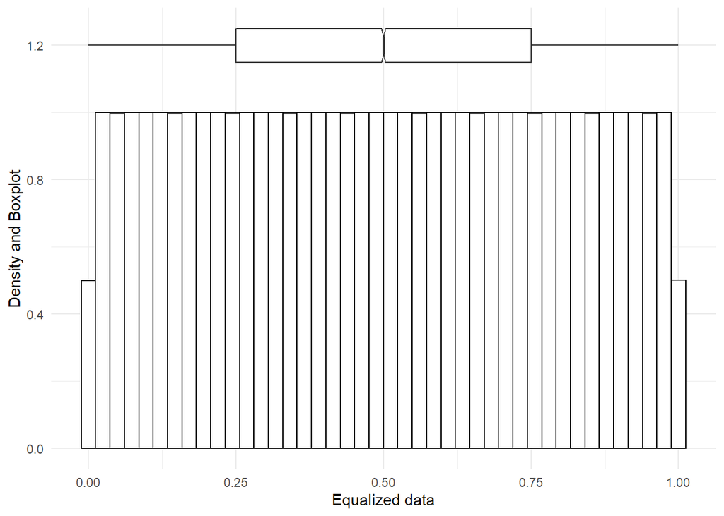

```r
vector.eq.bright <- data.frame(eq.bright=as.vector(eq.bright))

ggplot(vector.eq.bright, aes(x=eq.bright)) +
  geom_histogram(aes(y=..density..),
                 bins=nclass.FD(unlist(vector.eq.bright)),
                 col="black", fill="white") +
  geom_boxplot(aes(y=1.2), width=.1, notch=TRUE) +
  ylab("Density and Boxplot") +
  xlab("Equalized data")
```

In the figure above, it can be shown that after the transformation, the new image has a uniform pixel distribution.

For the sake of simplicity, we can also directly perform a logarithmic transformation of the data, and the result is shown in the figure below.

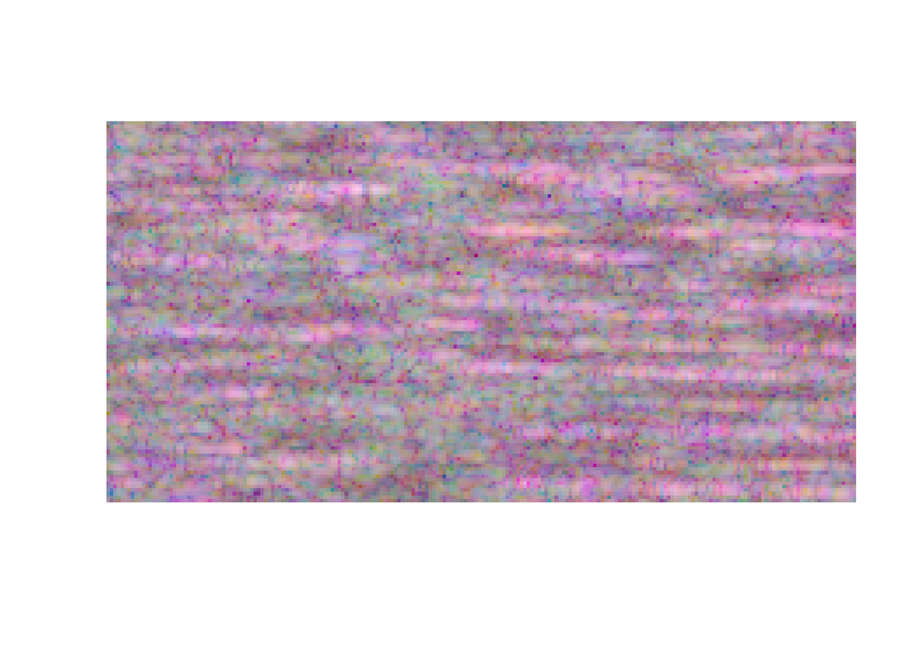

```r
plot(imagematrix(normalize(log(bright))))
```

When changing the parameters in the histogram, we can see the following results. We can perform an example of this effect with a sample of size $n=300$.

#Gamma Distribution

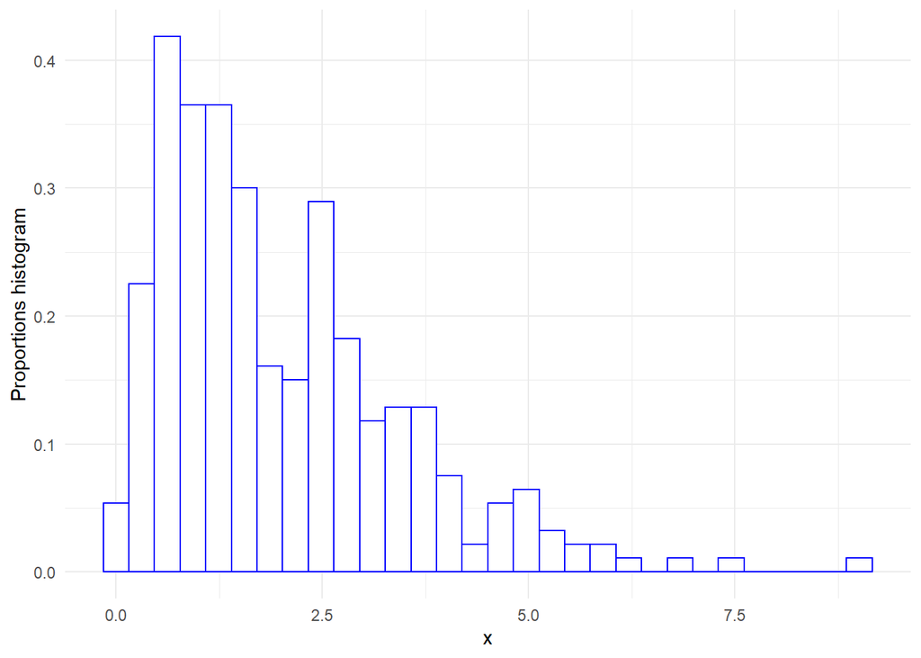

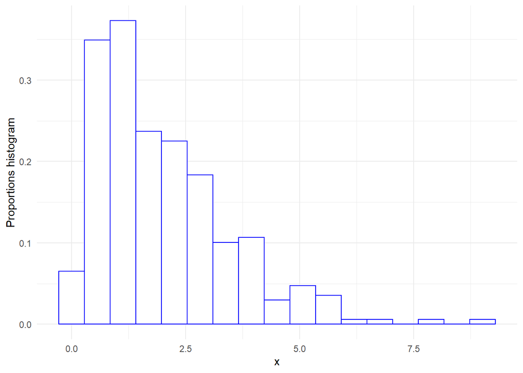

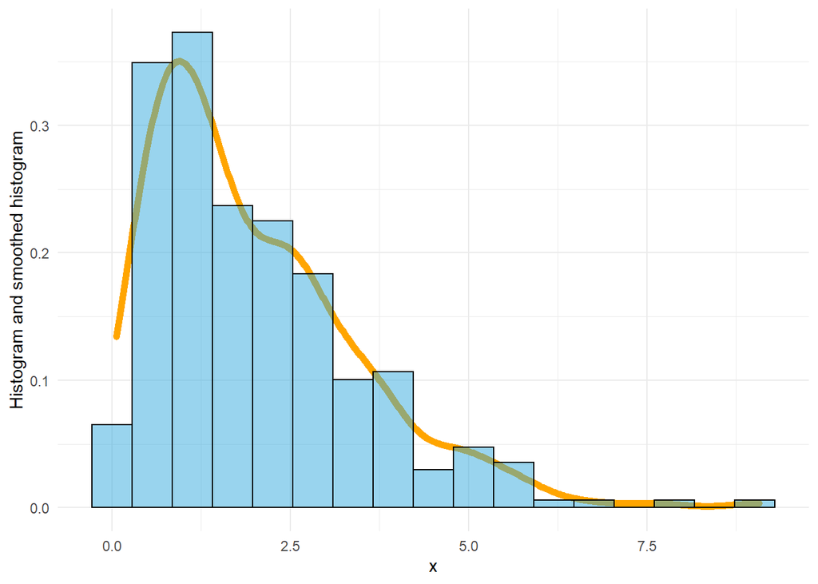

Histograms

```r
x <- data.frame(x=rgamma(300, shape=2, scale=1))

ggplot(x, aes(x=x)) +
  geom_histogram(aes(y=..density..),
                 col="blue", fill="white") +
  ylab("Proportions histogram")
ggplot(x, aes(x=x)) +
  geom_histogram(aes(y=..density..),
                 bins=nclass.FD(unlist(x)),
                 col="blue", fill="white") +
  ylab("Proportions histogram")

ggplot(x, aes(x=x)) +
  geom_density(col="orange", size=2) +
  geom_histogram(aes(y=..density..),
                 bins=nclass.FD(unlist(x)),
                 alpha=0.5, fill="#33AADE", color="black") +
  ylab("Histogram and smoothed histogram")
```

By comparing the first and second graphs, the results show that the larger the number of boxes, the more data it can be got and the more difficult it is to process.

#The definition of K-Distribution

```r
# This block is the K PDF & K-distributions random generator.
dKI <- function(z, p_alpha, p_lambda, p_Looks, log=FALSE) {

  if(log==FALSE) {

    lLz <- p_lambda * p_Looks* z

    return((2*p_lambda*p_Looks/(gamma(p_alpha)*gamma(p_Looks))) *
             (lLz)^((p_alpha+p_Looks)/2-1) *
             besselK(x = 2*sqrt(lLz), nu = p_alpha-p_Looks)
    )
  }

}


rKI <- function(n, p_alpha,p_lambda, p_Looks) {

  return(
    rgamma(n, 1, p_Looks)*rgamma(n, p_alpha/p_lambda, p_alpha)
  )

}
```

#The definition of G0-Distribution

```r
# This block is the G0 PDF & G0-distributions random generator.
dGI0 <- function(z, p_alpha, p_gamma, p_Looks, log=FALSE) {

  if(log==TRUE) {
    return(
      (p_Looks*log(p_Looks) + lgamma(p_Looks-p_alpha) + (p_Looks-1)*log(z) ) -
        (p_alpha*log(p_gamma) + lgamma(-p_alpha) + lgamma(p_Looks) +
        (p_Looks-p_alpha)*log(p_gamma + z*p_Looks) )
      )
    }
  else { return(
    ( p_Looks^p_Looks * gamma(p_Looks-p_alpha) * z^(p_Looks-1) ) /
    (p_gamma^p_alpha * gamma(-p_alpha) * gamma(p_Looks) * (p_gamma + z*p_Looks)^(p_Looks-p_alpha))
  )
  }
}


rGI0 <- function(n, p_alpha, p_gamma, p_Looks) {

  return(
    rgamma(n, 1, p_Looks) / rgamma(n, -p_alpha, p_gamma)
  )

}
```

#Different parameters for the Gamma-Distribution

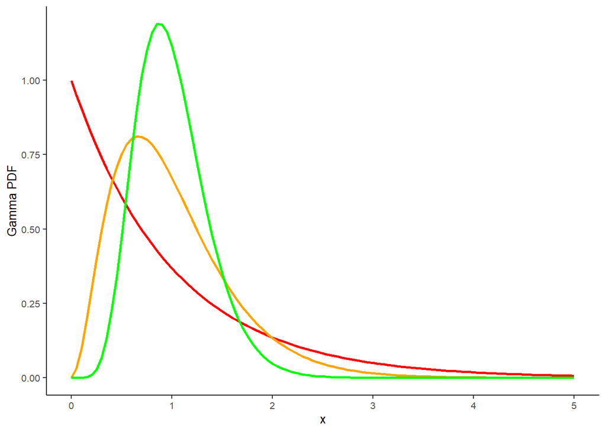

```r
# Gamma Distributions (PDF & CDF)
ggplot(data=data.frame(x=seq(1e-3, 5, length.out = 1e3)), aes(x=x)) +
  stat_function(fun=dgamma, geom = "line", size=1, col="red", args = list(shape=1, scale=1)) +
  stat_function(fun=dgamma, geom = "line", size=1, col="orange", args = list(shape=3, scale=1/3)) +
  stat_function(fun=dgamma, geom = "line", size=1, col="green", args = list(shape=8, scale=1/8)) +
  theme_classic() +
  theme(text = element_text(size=10)) +
  xlab("x") + ylab("Gamma PDF")
```

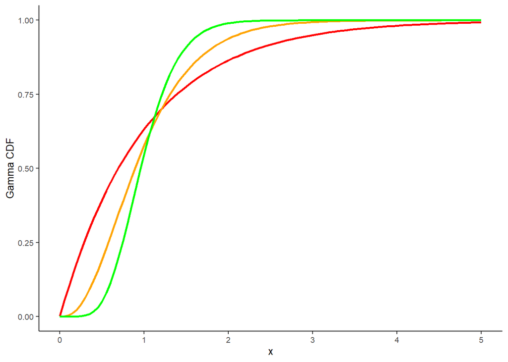

```r
ggplot(data=data.frame(x=seq(1e-3, 5, length.out = 1e3)), aes(x=x)) +
  stat_function(fun=pgamma, geom = "line", size=1, col="red", args = list(shape=1, scale=1)) +
  stat_function(fun=pgamma, geom = "line", size=1, col="orange", args = list(shape=3, scale=1/3)) +
  stat_function(fun=pgamma, geom = "line", size=1, col="green", args = list(shape=8, scale=1/8)) +
  theme_classic() +
  theme(text = element_text(size=10)) +
  xlab("x") + ylab("Gamma CDF")
```

#Different parameters for the K-Distribution

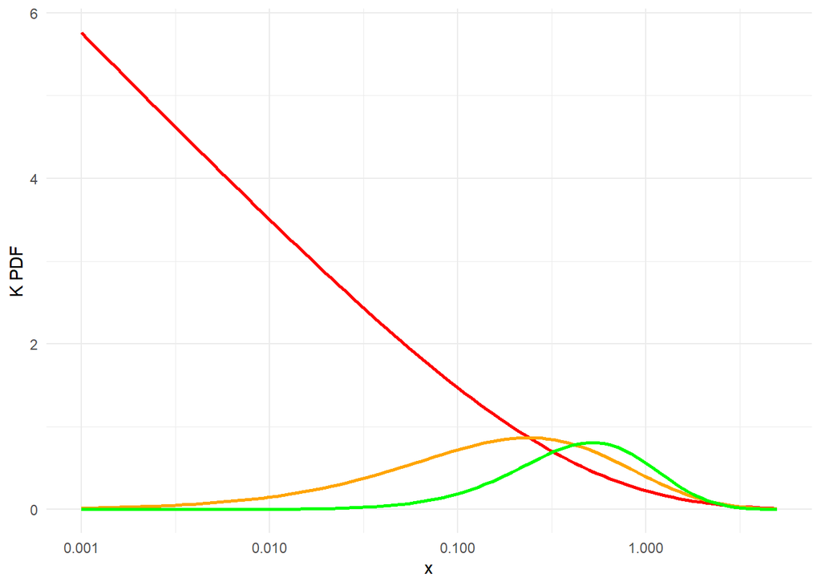

```r
# K Distributions (PDF)
ggplot(data=data.frame(x=seq(1e-3, 5, length.out = 1e3)), aes(x=x)) +
  stat_function(fun=dKI, geom = "line", size=1, col="red", args = list(p_alpha=1, p_lambda=1, p_Looks=1)) +
  stat_function(fun=dKI, geom = "line", size=1, col="orange", args = list(p_alpha=3, p_lambda=3, p_Looks=2)) +
  stat_function(fun=dKI, geom = "line", size=1, col="green", args = list(p_alpha=8, p_lambda=8, p_Looks=3)) +
  xlab("x") +
  ylab("K PDF")+
  scale_x_log10()
```

#Different parameters for the G0-Distribution

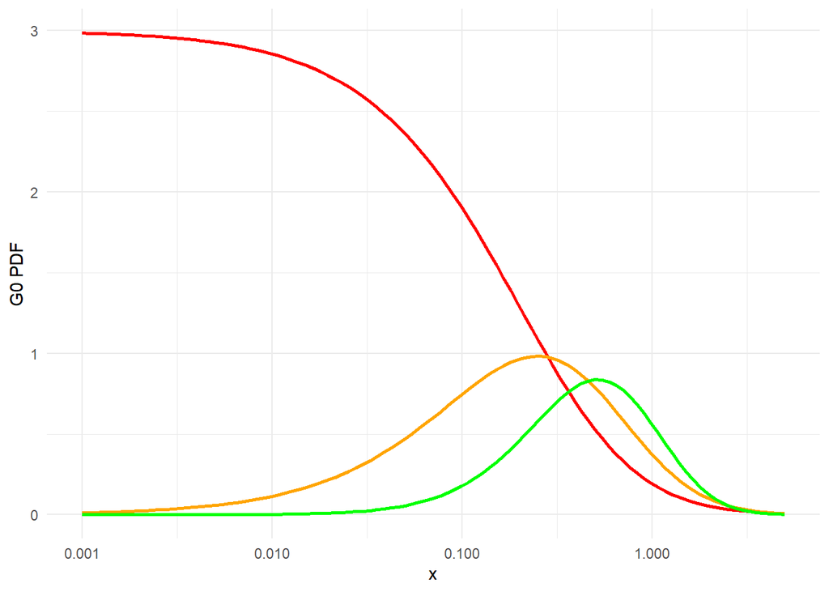

```r
# G0 Distributions (PDF)
ggplot(data=data.frame(x=seq(1e-3, 5, length.out = 1e3)), aes(x=x)) +
  stat_function(fun=dGI0, geom = "line", size=1, col="red", args = list(p_alpha=-1.5, p_gamma=.5, p_Looks=1)) +
  stat_function(fun=dGI0, geom = "line", size=1, col="orange", args = list(p_alpha=-3, p_gamma=2, p_Looks=2)) +
  stat_function(fun=dGI0, geom = "line", size=1, col="green", args = list(p_alpha=-8, p_gamma=7, p_Looks=3)) +
  xlab("x") + ylab("G0 PDF")+
  scale_x_log10()
```

#Random number generator for K(p_alpha, p_lambda, p_Looks)

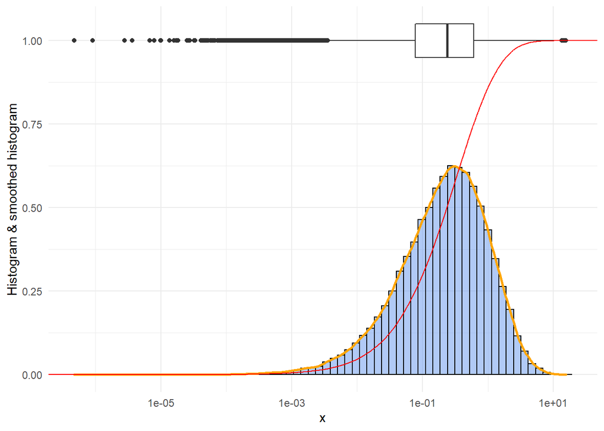

```r
# k-distribution random generator
p_alpha=3
p_lambda=2
p_Looks=1
pk_num=1e5

# K-random
x<-rKI(pk_num, p_alpha, p_lambda, p_Looks)
x<-data.frame(x) # x~K(p_alpha, p_lambda, p_Looks)

ggplot(x, aes(x=x)) +
  geom_histogram(aes(y=..density..),alpha=0.5, fill="#6495ED",        color="black",bins=nclass.FD(unlist(x))/10) +
  geom_density(col="orange", size=1) +
  geom_boxplot(aes(y=1), width=.1)+
  stat_ecdf(col="red") +
  ylab("Histogram & smoothed histogram")+
  scale_x_log10()
```

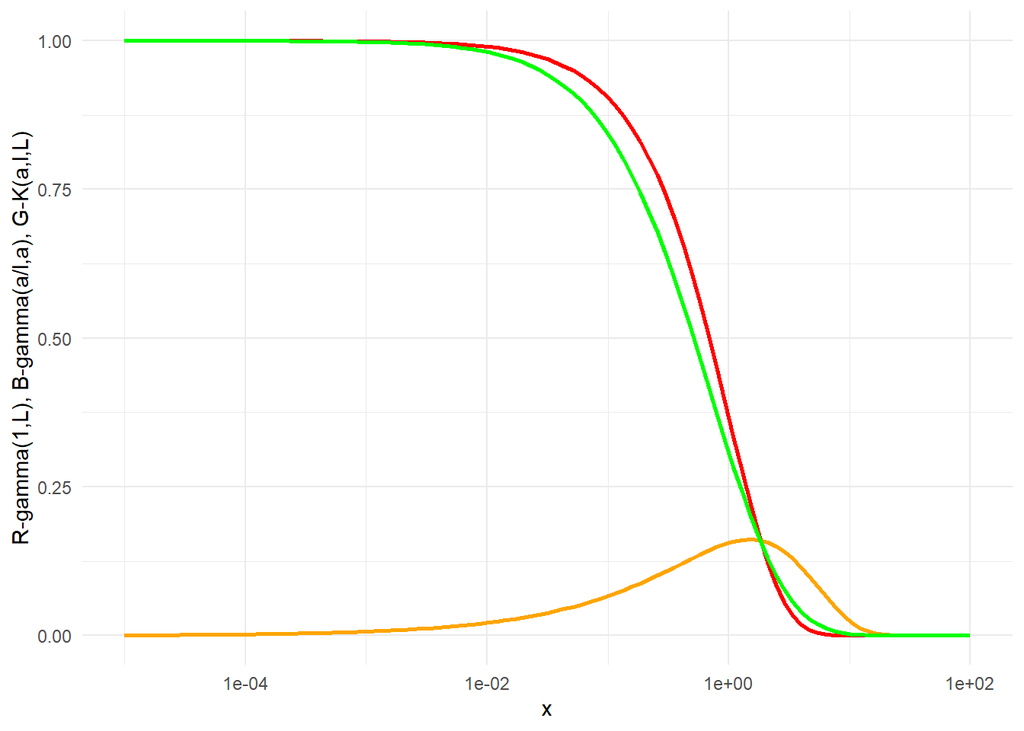

```r
ggplot(data=data.frame(x=seq(1e-5, 1e2, length.out = 1e5)), aes(x=x)) +
  stat_function(fun=dgamma, geom = "line", size=1, col="red", args = list(shape=1, scale=p_Looks)) +
  stat_function(fun=dgamma, geom = "line", size=1, col="orange", args = list(shape=p_alpha/p_lambda, scale=p_alpha)) +
  stat_function(fun=dKI, geom = "line", size=1, col="green", args = list(p_alpha=p_alpha, p_lambda=p_lambda, p_Looks=p_Looks)) +
  xlab("x") + ylab("R-gamma(1,L), B-gamma(a/l,a), G-K(a,l,L)")+
  scale_x_log10()
```

#Random number generator for G0(p_alpha, p_gamma, p_Looks)

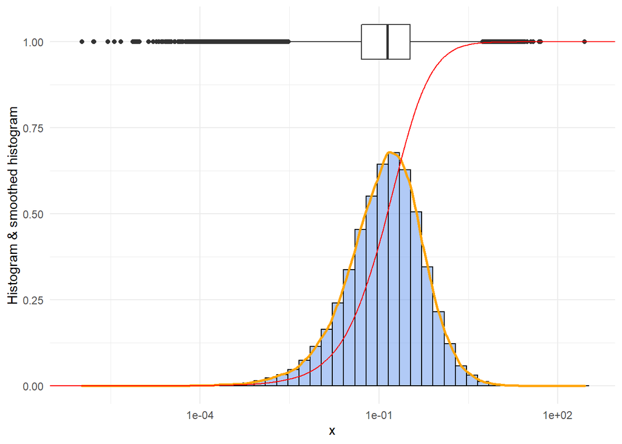

```r
# G0-distribution random generator
p_alpha=-2
p_gamma=.5
p_Looks=1.5
pG0_num=1e5

# G0-random
x<-rGI0(pG0_num,p_alpha, p_gamma, p_Looks)
x<-data.frame(x) # x~G0(p_alpha, p_gamma, p_Looks)

ggplot(x, aes(x=x)) +
  geom_histogram(aes(y=..density..),alpha=0.5, fill="#6495ED",        color="black",bins=nclass.FD(unlist(x))/500) +
  geom_density(col="orange", size=1) +
  geom_boxplot(aes(y=1), width=.1)+
  stat_ecdf(col="red") +
  ylab("Histogram & smoothed histogram")+
  scale_x_log10()
```

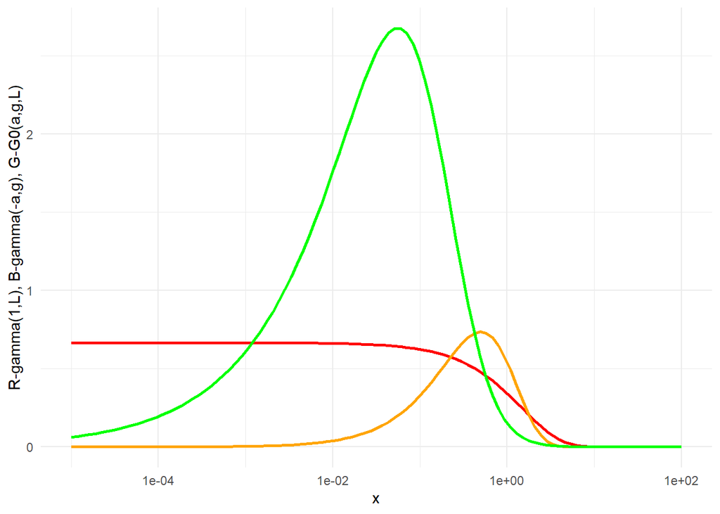

```r
ggplot(data=data.frame(x=seq(1e-5, 1e2, length.out = 1e5)), aes(x=x)) +
  stat_function(fun=dgamma, geom = "line", size=1, col="red", args = list(shape=1, scale=p_Looks)) +
  stat_function(fun=dgamma, geom = "line", size=1, col="orange", args = list(shape=-p_alpha, scale=p_gamma)) +
  stat_function(fun=dGI0, geom = "line", size=1, col="green", args = list(p_alpha=p_alpha, p_gamma=p_gamma, p_Looks=p_Looks)) +
  xlab("x") + ylab("R-gamma(1,L), B-gamma(-a,g), G-G0(a,g,L)")+
  scale_x_log10()
```